**Physics-informed Neural Networks (PINN)**

By Prof. Seungchul Lee  
http://iailab.kaist.ac.kr/  
Industrial AI Lab at KAIST

Table of Contents

# 1. Why Deep Learning Needs Physics?

(1) Advantages of Data-Driven Approaches

When sufficient data is available, data-driven models can achieve a high level of predictive accuracy without requiring extensive domain knowledge. These methods leverage large-scale datasets to learn complex patterns, making them effective for a wide range of applications.

(2) Challenges of Black-Box Data-Driven Methods

Despite their predictive capabilities, purely data-driven models, particularly black-box approaches, face several limitations:

- They may produce physically inconsistent results.
- They are prone to learning spurious correlations that appear valid only within the training and test datasets.
- They often exhibit poor generalization, particularly when applied to out-of-sample prediction tasks.
- The lack of interpretability hinders scientific understanding and trust in the model's predictions.
- Understanding the underlying mechanisms governing a system is essential for scientific discovery and real-world applicability.

(3) Limitations of Purely Data-Driven Approaches

- **Limited Generalizability:** Models struggle with out-of-distribution data, reducing reliability in real-world scenarios.
- **Lack of Interpretability:** Predictions often lack physical meaning, making it difficult to extract scientifically relevant insights.

(4) Physics-Informed Neural Networks (PINNs)

To address these challenges, Physics-Informed Neural Networks (PINNs) integrate scientific domain knowledge into deep learning models. PINNs:

- Combine the strengths of data-driven methods with established physical laws, improving predictive accuracy and robustness.
- Help mitigate issues related to imbalanced datasets and data scarcity by enforcing known physical constraints.
- Enhance interpretability by ensuring outputs align with fundamental scientific principles, making them more reliable for real-world applications.

By embedding prior knowledge from physics and engineering, PINNs provide a more generalizable, interpretable, and physically consistent framework for deep learning, overcoming the limitations of purely data-driven methods.

## 1.1. Taxonomy of Physics-informed Deep Learning

**Deep Neural Networks**:

Each type of DNN architecture is tailored to handle specific data structures and tasks:

- ANN (Artificial Neural Networks): Basic neural network structures that form the foundation of deep learning.
- CNN (Convolutional Neural Networks): Designed primarily for tasks like image recognition and feature extraction.
- RNN (Recurrent Neural Networks): Specialized for sequential data processing, such as time series or natural language tasks.
- GNN (Graph Neural Networks): Utilized for processing graph-structured data, like social networks or molecular structures.
- Generative Models: Models like GANs and VAEs for creating new data samples from learned distributions.

**Knowledge Representation**:

Knowledge representation refers to how domain-specific knowledge is encoded to be accessible and actionable for Deep Neural Networks. The choice of representation plays a critical role in enhancing learning efficiency and interpretability:

- Differential Equations: Used for modeling continuous dynamical systems.
- Algebraic Equations: Represent mathematical relationships and constraints.
- Knowledge Graphs: Capture relational and semantic information between entities.
- Simulation Results: Provide structured outputs from computational simulations.
- Human Feedback: Incorporates expert insights and manual annotations.

**Knowledge Integration**:

Integrating external knowledge into DNNs is a critical step to ensure that models not only rely on large datasets but also leverage existing domain knowledge. This improves model accuracy, generalizability, and interpretability:

- Feature Engineering: Tailoring input features to better align with domain-specific knowledge.
- Designing: Modifying model architectures to incorporate external knowledge sources.
- Regularizing: Adding constraints, priors, or penalties to the loss function ensures that the model adheres to known properties of the domain. This prevents overfitting and encourages the model to find solutions consistent with real-world knowledge.

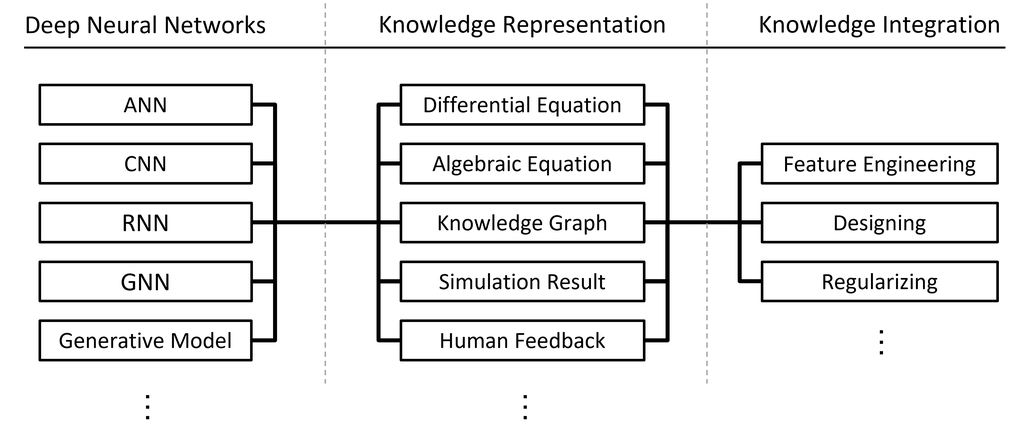

## 1.2. Multilayer Feedforward Networks are Universal Approximators

The Universal Approximation Theorem (1989)

- Neural Networks are capable of approximating any Borel measurable function
- A foundational result in the theory of neural networks, stating that a feedforward neural network with at least one hidden layer and a finite number of neurons can approximate any continuous function to arbitrary accuracy, given sufficient neurons and an appropriate activation function.

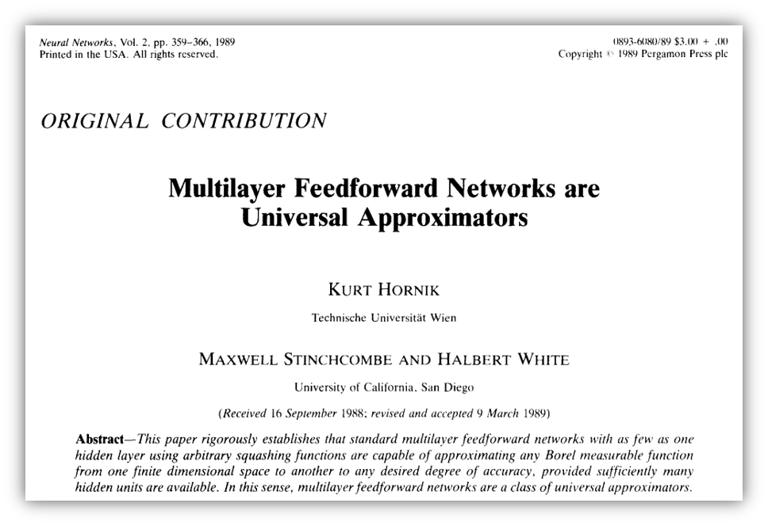

## 1.3. Neural Networks for Solving Differential Equations

Neural networks have emerged as a powerful tool for solving differential equations, offering a flexible and efficient alternative to traditional numerical methods. By leveraging their ability to approximate complex functions, neural networks can model solutions to both ordinary differential equations (ODEs) and partial differential equations (PDEs). This approach is particularly advantageous for high-dimensional or nonlinear systems.

Two foundational works on the application of neural networks for solving differential equations are presented here.

- Neural Algorithm for Solving Differential Equations (1990)

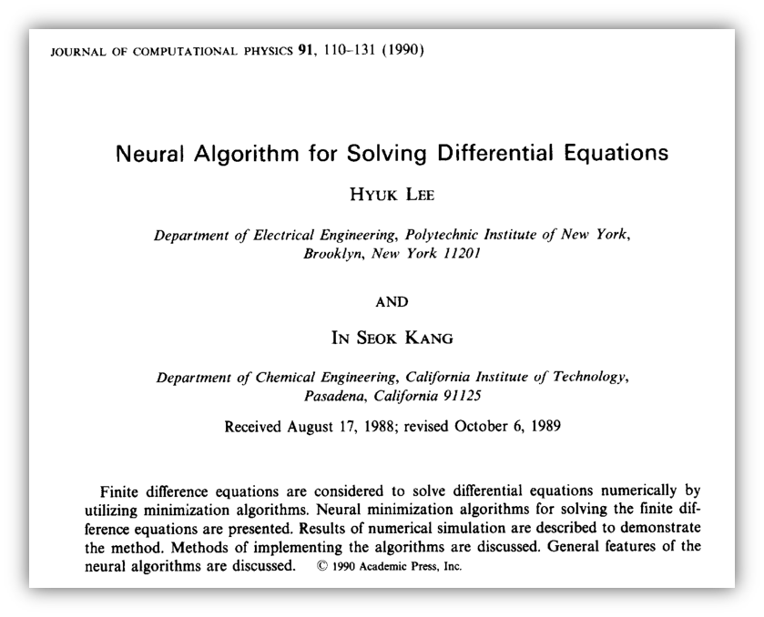

- ANN for ODE and PDE (1998)

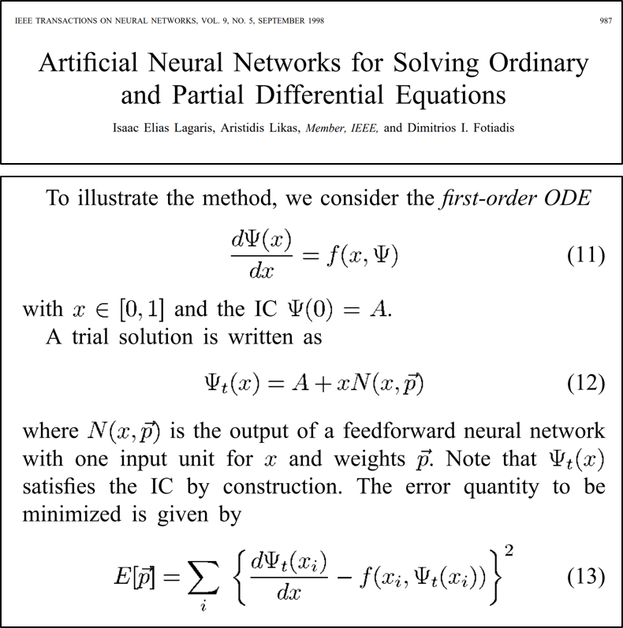

## 1.4. Journal of Computational Physics (2019)

The following paper has played a significant role in advancing the field of Physics-informed Neural Networks (PINNs). It is highly recommended for those interested in this emerging area of research:

- Title: [Physics-informed neural networks: A deep learning framework for solving forward and inverse problems involving nonlinear partial differential equations](https://www.sciencedirect.com/science/article/pii/S0021999118307125)
- Link: https://maziarraissi.github.io/PINNs/

This groundbreaking work explores how deep learning can be leveraged to solve complex forward and inverse problems in nonlinear partial differential equations, providing a foundation for further advancements in combining deep learning with domain-specific knowledge.

[figure not shown]

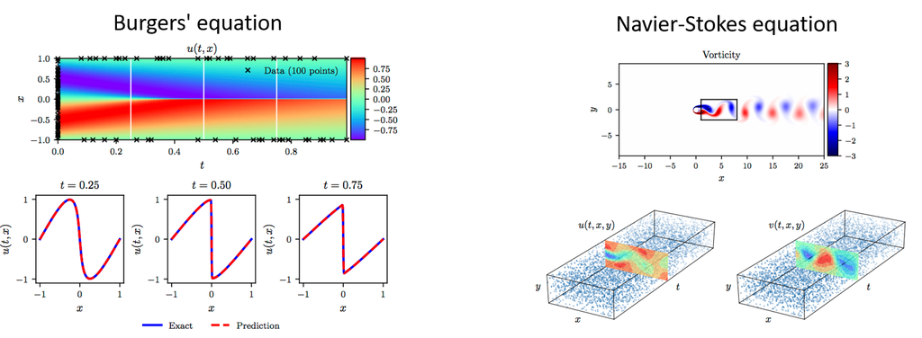

## 1.5. Nature Reviews Physics (2021)

The following paper explores several prevailing trends in embedding physics into machine learning, highlighting current capabilities, limitations, and diverse applications of physics-informed learning. This includes its use in solving both forward and inverse problems, uncovering hidden physical laws, and addressing high-dimensional challenges.

- [Physics-informed machine learning](https://www.nature.com/articles/s42254-021-00314-5)

[figure not shown]

# 2. Physics-Informed Neural Networks (PINNs) with PDE, IC, BC

Physics-Informed Neural Networks (PINNs) integrate the laws of physics, represented by partial differential equations (PDEs), along with initial and boundary conditions into the training process of neural networks. This approach makes them powerful for solving forward and inverse problems, even with limited or noisy data.

**Key Formulation**

Consider a generic time-dependent PDE defined on a domain $ \Omega \times [0, T] $:

$$ \mathcal{N}[u(x, t)] = f(x, t), \quad (x, t) \in \Omega \times [0, T], $$

where:

- $ \mathcal{N} $ is a differential operator involving derivatives of $ u(x, t) $,
- $ u(x, t) $ is the unknown solution to be approximated,
- $ f(x, t) $ is a source or forcing term,
- $ \Omega $ is the spatial domain, and $[0, T]$ is the temporal interval.

**Initial and Boundary Conditions**

To uniquely solve the PDE, we include:

(1) Initial Condition: Specifies the solution at the start of the time domain:

$$ u(x, 0) = g(x), \quad x \in \Omega. $$

(2) Boundary Conditions: Specifies the behavior of the solution at the spatial domain boundaries. For example:

- Dirichlet Boundary Condition:

$$ u(x_b, t) = h_1(x_b, t), \quad x_b \in \partial \Omega, \, t \in [0, T]. $$

- Neumann Boundary Condition:

$$ \frac{\partial u}{\partial n}(x_b, t) = h_2(x_b, t), \quad x_b \in \partial \Omega, \, t \in [0, T]. $$

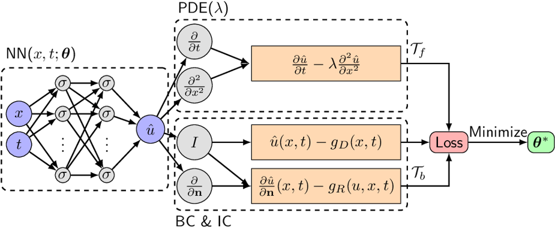

**PINN Loss Function**

PINNs approximate the solution $ u(x, t) $ using a neural network $ u_\theta(x, t) $, parameterized by $ \theta $. The training involves minimizing a total loss function composed of the following components:

(1) Physics Equation (PDE):

$$ \mathcal{L}_{\text{physics}} = \frac{1}{N_f} \sum_{i=1}^{N_f} \left| \mathcal{N}[u_\theta(x_i, t_i)] - f(x_i, t_i) \right|^2, $$

where $ \{(x_i, t_i)\}_{i=1}^{N_f} $ are collocation points sampled from the domain $ \Omega \times [0, T] $.

(2) Initial Condition:

$$ \mathcal{L}_{\text{initial}} = \frac{1}{N_I} \sum_{i=1}^{N_I} \left| u_\theta(x_i, 0) - g(x_i) \right|^2, $$

where $ \{x_i\}_{i=1}^{N_I} $ are points sampled from $ \Omega $ at $ t = 0 $.

(3) Boundary Conditions:

For Dirichlet boundary conditions:

$$ \mathcal{L}_{\text{Dirichlet}} = \frac{1}{N_B} \sum_{i=1}^{N_B} \left| u_\theta(x_b, t_i) - h_1(x_b, t_i) \right|^2, $$

where $ \{(x_b, t_i)\}_{i=1}^{N_B} $ are points sampled on the boundary $ \partial \Omega $.

For Neumann boundary conditions:

$$ \mathcal{L}_{\text{Neumann}} = \frac{1}{N_B} \sum_{i=1}^{N_B} \left| \frac{\partial u_\theta}{\partial n}(x_b, t_i) - h_2(x_b, t_i) \right|^2. $$

(4) Total Loss Function:

The total loss function combines all components:

$$ \mathcal{L}_{\text{total}} = \mathcal{L}_{\text{physics}} + \lambda_I \mathcal{L}_{\text{initial}} + \lambda_B \mathcal{L}_{\text{boundary}}, $$

where $ \lambda_I $ and $ \lambda_B $ are weights to balance the contributions of initial and boundary losses.

By encoding physical laws and constraints directly into the learning process, PINNs offer a robust and data-efficient framework for solving challenging real-world problems.

# 3. Inverse Problems using Observed Data

We investigate the potential of Physics-informed Neural Networks (PINNs) as a neural network-based approach for solving forward problems. However, this method does not offer significant advantages over conventional computational techniques. In contrast, the application of PINNs for inverse problem-solving presents a promising new opportunity for advancing scientific computing.

Inverse problems involve determining unknown parameters, functions, or hidden physical laws from observed data. PINNs provide a robust framework for solving these problems by integrating both observed data and physical constraints from governing equations.

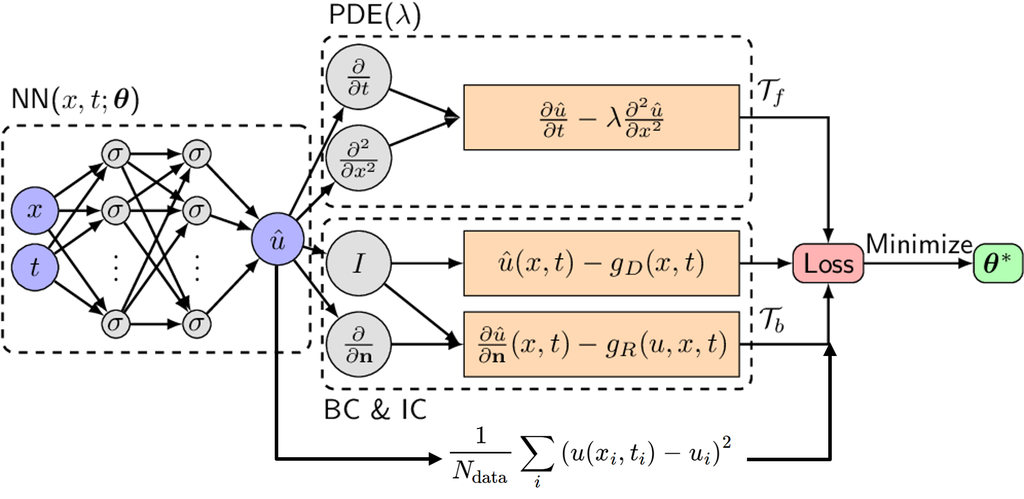

Let's examine how PINNs can be used to estimate unknown parameters, serving as an example of solving inverse problems.

**Formulation of an Inverse Problem with PINNs**

Given a system governed by a partial differential equation (PDE):

$$ \mathcal{N}[u(x, t; \lambda)] = f(x, t), \quad (x, t) \in \Omega \times [0, T], $$

where:

- $ \mathcal{N} $ is a differential operator acting on the unknown solution $ u(x,t) $,
- $ \lambda $ is an unknown parameter or function to be inferred,
- $ f(x, t) $ is a known forcing term,
- $ \Omega $ is the spatial domain, and $ [0, T] $ is the temporal interval.

The goal is to **estimate** $ \lambda $ given a set of **observed data points**:

$$ \{ (x_i, t_i, u_{\text{obs}}(x_i, t_i) ) \}_{i=1}^{N_d}. $$

PINNs solve this problem by learning both the solution $ u_\theta(x,t) $ and the unknown parameter $ \lambda $ simultaneously.

**Loss Function for the Inverse Problem**

To estimate $ \lambda $, we define a composite loss function that minimizes:

1. Physics Residual Loss: Ensures the PDE is satisfied at collocation points:
   $$ \mathcal{L}_{\text{physics}} = \frac{1}{N_f} \sum_{i=1}^{N_f} \left| \mathcal{N}[u_\theta(x_i, t_i; \lambda)] - f(x_i, t_i) \right|^2. $$
2. Initial Condition Loss: Enforces the initial condition of the system:
   $$ \mathcal{L}_{\text{initial}} = \frac{1}{N_I} \sum_{i=1}^{N_I} \left| u_\theta(x_i, 0) - g(x_i) \right|^2. $$
3. Boundary Condition Loss: Enforces boundary conditions:
   $$ \mathcal{L}_{\text{boundary}} = \frac{1}{N_B} \sum_{i=1}^{N_B} \left| u_\theta(x_b, t_i) - h_1(x_b, t_i) \right|^2. $$
4. Data Loss: Ensures the predicted solution matches the observed data:
   $$ \mathcal{L}_{\text{data}} = \frac{1}{N_d} \sum_{i=1}^{N_d} \left| u_\theta(x_i, t_i) - u_{\text{obs}}(x_i, t_i) \right|^2. $$
5. Total Loss Function: Combining all components:
   $$ \mathcal{L}_{\text{total}} = \mathcal{L}_{\text{physics}} + \lambda_I \mathcal{L}_{\text{initial}} + \lambda_B \mathcal{L}_{\text{boundary}} + \lambda_D \mathcal{L}_{\text{data}}. $$
   where $ \lambda_I, \lambda_B, \lambda_D $ are weights that balance the contributions of each loss term.

By combining observed data with known physics, PINNs provide a powerful framework for solving inverse problems across various scientific and engineering domains.

# 4. PINN Implementation

We have discussed the fundamental theory behind Physics-informed Neural Networks (PINNs); now, let's explore how PINNs are implemented in practice. This will involve constructing the neural network, defining the loss function incorporating physical constraints, and training the model to solve forward problems.

## 4.1. Lab 1: Simple Example

Here, we will begin with the simplest example of an ordinary differential equation (ODE), which will be implemented from scratch using Keras.

- Let's look at the ODE:

$$\frac{du}{dt} = \cos2\pi t$$

- Initial condition:

$$u(0) = 1$$

- The exact solution:

$$u(t) = \frac{1}{2\pi}\sin2\pi t + 1$$

- Make a neural network and loss functions like below:

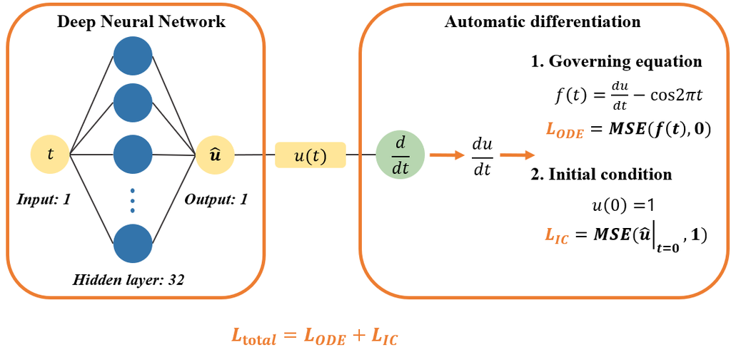

**Import Library**

```python
import numpy as np
import matplotlib.pyplot as plt
import tensorflow as tf
tf.compat.v1.enable_eager_execution()
import random
import warnings
warnings.filterwarnings("ignore")
```

**Define Network and Hyper-parameters**

```python
NN = tf.keras.models.Sequential([
    tf.keras.layers.Input((1,)),
    tf.keras.layers.Dense(units = 32, activation = 'tanh'),
    tf.keras.layers.Dense(units = 32, activation = 'tanh'),
    tf.keras.layers.Dense(units = 1)
])

NN.summary()
```

```
Model: "sequential"
```

```
┏━━━━━━━━━━━━━━━━━━━━━━━━━━━━━━━━━━━━━━┳━━━━━━━━━━━━━━━━━━━━━━━━━━━━━┳━━━━━━━━━━━━━━━━━┓
┃ Layer (type)                         ┃ Output Shape                ┃         Param # ┃
┡━━━━━━━━━━━━━━━━━━━━━━━━━━━━━━━━━━━━━━╇━━━━━━━━━━━━━━━━━━━━━━━━━━━━━╇━━━━━━━━━━━━━━━━━┩
│ dense (Dense)                        │ (None, 32)                  │              64 │
├──────────────────────────────────────┼─────────────────────────────┼─────────────────┤
│ dense_1 (Dense)                      │ (None, 32)                  │           1,056 │
├──────────────────────────────────────┼─────────────────────────────┼─────────────────┤
│ dense_2 (Dense)                      │ (None, 1)                   │              33 │
└──────────────────────────────────────┴─────────────────────────────┴─────────────────┘
```

```
 Total params: 1,153 (4.50 KB)
```

```
 Trainable params: 1,153 (4.50 KB)
```

```
 Non-trainable params: 0 (0.00 B)
```

```python
optm = tf.keras.optimizers.Adam(learning_rate = 0.001)
```

**Define ODE System**

- ODE loss:

$$L_{\text{ODE}} = \frac{1}{N_f}\sum_{i=1}^{N_f} \left(\frac{d \text{u}(t_i)}{dt}- \cos2\pi t_i\right)^2$$

- Initial condition loss:

$$L_{IC} = \frac{1}{N_I}\sum_{i=1}^{N_I} \left({\text{u}(0)}- 1\right)^2$$

- Total loss:

$$L_{\text{Total}} = L_{\text{ODE}} + L_{\text{IC}}$$

```python
def ode_system(t, net):
    t = t.reshape(-1,1)
    t = tf.constant(t, dtype = tf.float32)

    t_0 = tf.zeros((1,1))
    one = tf.ones((1,1))

    with tf.GradientTape() as tape:
        tape.watch(t)

        u = net(t)                    # Calculate the ODE loss
        u_t = tape.gradient(u, t)     # Calculate the Initial Condition loss

    ode_loss = u_t - tf.math.cos(2*np.pi*t)
    IC_loss = net(t_0) - one

    square_loss = tf.square(ode_loss) + tf.square(IC_loss)
    total_loss = tf.reduce_mean(square_loss)

    return total_loss
```

**Train & Prediction**

```
1.5481387
0.39919287
0.11245116
```

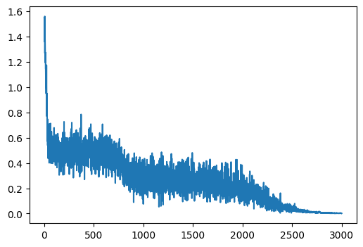

```python
train_loss_record = []

for itr in range(3000):
  train_t = (np.random.rand(20)*2).reshape(-1, 1)

  with tf.GradientTape() as tape:
    train_loss = ode_system(train_t, NN)
    train_loss_record.append(train_loss)

    grad_w = tape.gradient(train_loss, NN.trainable_variables)
    optm.apply_gradients(zip(grad_w, NN.trainable_variables))

  if itr % 1000 == 0:
      print(train_loss.numpy())

plt.figure(figsize = (6, 4))
plt.plot(train_loss_record)
plt.show()
```

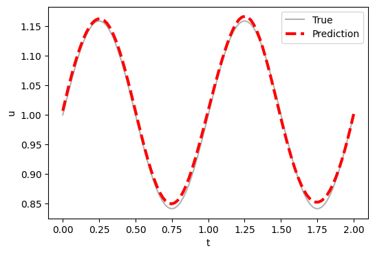

```python
test_t = np.linspace(0, 2, 100)
test_t = tf.constant(test_t, dtype = tf.float32)

pred_u = NN(test_t).numpy()
true_u = np.sin(2*np.pi*test_t)/(2*np.pi) + 1

plt.figure(figsize = (6, 4))
plt.plot(test_t, true_u, 'k', label = 'True', alpha = 0.3)
plt.plot(test_t, pred_u, '--r', label = 'Prediction', linewidth = 3)
plt.legend()
plt.xlabel('t')
plt.ylabel('u')
plt.show()
```

## 4.2. Lab 2: Solve Lab 1 Again using DeepXDE

As Physics-informed Neural Networks (PINNs) have gained increasing attention, **DeepXDE**, a framework specifically designed for PINNs, has been developed by [Prof. Lu Lu](https://lugroup.yale.edu/). Here, we will solve the same example presented above using DeepXDE.

### 4.2.1. DeepXDE

- Using [DeepXDE](https://deepxde.readthedocs.io/en/latest/) libray
- DeepXDE is a useful library for solving forward and inverse partial differential equations (PDEs) via physics-informed neural network (PINN)

```python
!pip install deepxde
```

[output not shown]

- Change DeepXDE backends
  - DeepXDE supports backends for TensorFlow 1.x, TensorFlow 2.x, and PyTorch. We have to change it into TensorFlow 2.x

```python
from deepxde.backend.set_default_backend import set_default_backend
set_default_backend("tensorflow")
```

[output not shown]

```
No backend selected.
Finding available backend...
Found tensorflow.compat.v1
Setting the default backend to "tensorflow.compat.v1". You can change it in the ~/.deepxde/config.json file or export the DDE_BACKEND environment variable. Valid options are: tensorflow.compat.v1, tensorflow, pytorch, jax, paddle (all lowercase)
Setting the default backend to "tensorflow". You can change it in the ~/.deepxde/config.json file or export the DDE_BACKEND environment variable. Valid options are: tensorflow.compat.v1, tensorflow, pytorch, jax, paddle (all lowercase)
```

### 4.2.2. Problem Setup Again

- ODE

$$\frac{du}{dt} = \cos2\pi t$$

- Boundary condition:

$$u(0) = 1$$

- The exact solution:

$$u(t) = \frac{1}{2\pi}\sin2\pi t + 1$$

**Import Library**

```python
import tensorflow as tf
import deepxde as dde
import numpy as np
import matplotlib.pyplot as plt
import math as m
```

**Define ODE System**

```python
pi = tf.constant(m.pi)

def ode_system(t, u):
    du_t = dde.grad.jacobian(u, t)
    return du_t - tf.math.cos(2*pi*t)
```

**Define Initial Condition**

```python
def boundary(t, on_initial):
    return on_initial and np.isclose(t[0], 0)
```

**Define Geometry & Implement Initial Condition**

```python
geom = dde.geometry.TimeDomain(0, 2)

ic = dde.IC(geom, lambda t: 1, boundary)

# Reference solution to compute the error
def true_solution(t):
    return np.sin(2*np.pi*t)/(2*np.pi) + 1

data = dde.data.PDE(geom,
                    ode_system,
                    ic,
                    num_domain = 30,
                    num_boundary = 2,
                    solution = true_solution,
                    num_test = 100)
```

**Define Network and Hyper-parameters**

```python
layer_size = [1] + [32] + [32] + [1]
activation = "tanh"
initializer = "Glorot uniform"

NN = dde.maps.FNN(layer_size, activation, initializer)
```

```python
model = dde.Model(data, NN)
model.compile("adam", lr = 0.001)
```

```
Compiling model...
Building feed-forward neural network...
'build' took 0.047398 s

'compile' took 0.227108 s
```

**Train & Prediction**

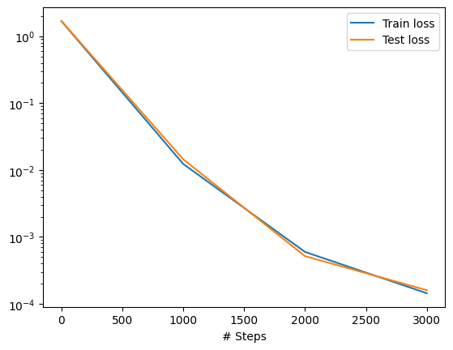

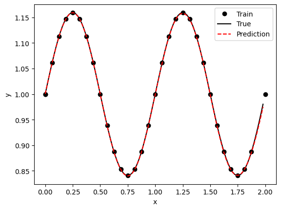

```python
losshistory, train_state = model.train(epochs = 3000)
dde.saveplot(losshistory, train_state, issave = False, isplot = True)
```

# 5. Lab 3: Euler Beam (Solid Mechanics)

Having explored the implementation of Physics-informed Neural Networks (PINNs) using both Keras and DeepXDE, we now extend our study to a more practical and familiar problem. Specifically, we will solve the Euler beam bending problem, a fundamental topic in solid mechanics. For this implementation, we will use PyTorch to implement the solution.

## 5.1. Problem Setup

- 1D problem

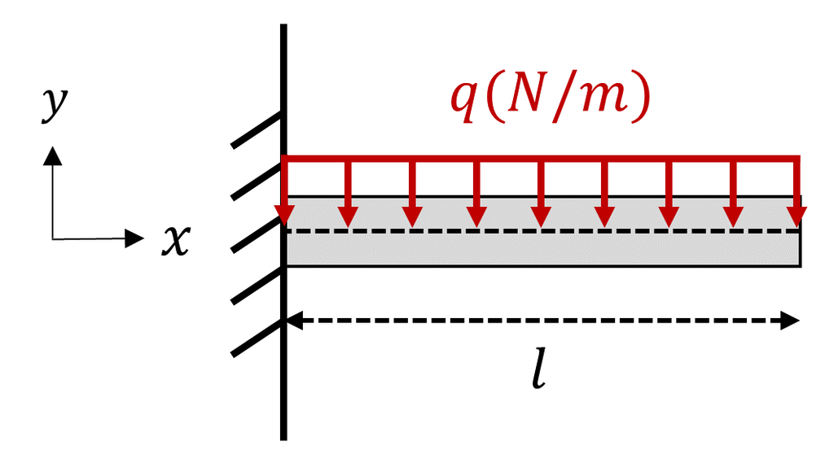

- Problem properties (nondimensionalized)

$$E = 1 \operatorname{pa}, \quad I = 1 \operatorname{kg\cdot m^2}, \quad q = 1 \operatorname{N/m}, \quad l = 1 \operatorname{m}$$

- Partial differential equations & boundary conditions

$${\partial^4 y \over \partial x^4} + q = 0, \qquad \text{where} \quad x \in [0,1]$$

- One Dirichlet boundary condition on the left boundary:

$$y(0) = 0$$

- One Neumann boundary condition on the left boundary:

$$y'(0) = 0$$

- Two boundary conditions on the right boundary:

$$y''(1) = 0, \quad y'''(1) = 0$$

- The exact solution is

$$y(x) = -{1 \over 24}x^4 + {1 \over 6}x^3 - {1 \over 4}x^2$$

- Make a neural network and loss functions like below :

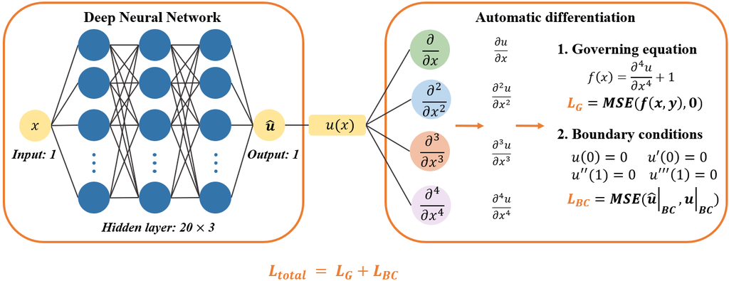

## 5.2. Solve the Euler Beam problem

**Import Library**

```python
import numpy as np
import torch
import matplotlib.pyplot as plt
import os
import warnings
warnings.filterwarnings("ignore")
```

```python
device = torch.device('cuda:0' if torch.cuda.is_available() else 'cpu')
print(device)
```

```
cuda:0
```

**Define Collocation Points**

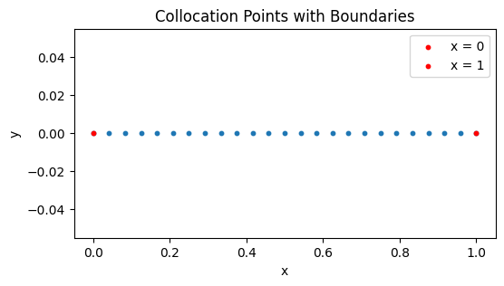

```python
x = np.linspace(0, 1, 25)
y = np.zeros_like(x)

x0 = x[0]               # Left boundary of x = 0
x1 = x[-1]              # Right boundary of x = 1

plt.figure(figsize = (6, 3))
plt.scatter(x, y, s = 10)
plt.scatter(x0, 0, label = 'x = 0', s = 10, c = 'red')
plt.scatter(x1, 0, label = 'x = 1', s = 10, c = 'red')
plt.xlabel('x')
plt.ylabel('y')
plt.legend()
plt.title('Collocation Points with Boundaries')
plt.show()
```

**Define Network and Hyper-parameters**

```python
import torch.nn as nn
from torch.nn import Linear, Tanh

class PINN(nn.Module):
    def __init__(self):
        super(PINN, self).__init__()
        self.net = nn.Sequential(
            Linear(1, 32),
            Tanh(),
            Linear(32, 32),
            Tanh(),
            Linear(32, 32),
            Tanh(),
            Linear(32, 32),
            Tanh(),
            Linear(32, 1),
            Tanh()
        )

    def forward(self, x):
        return self.net(x)

model = PINN().to(device)
optimizer = torch.optim.Adam(model.parameters(), lr = 1e-3)
loss_fn = nn.MSELoss()
```

**Define PDE System**

$$\frac{\partial^4 y}{\partial x^4} + q = 0, \qquad \text{where} \quad x \in [0,1]$$

```python
def derivative(f, t):
    return torch.autograd.grad(f,
                               t,
                               grad_outputs = torch.ones_like(f),
                               create_graph = True)[0]

def PDE(model, x):
    u = model(x)
    u_x = derivative(u, x)
    u_xx = derivative(u_x, x)
    u_xxx = derivative(u_xx, x)
    u_xxxx = derivative(u_xxx, x)

    pde = u_xxxx + 1
    return pde
```

**Define Boundary Condition**

- One Dirichlet boundary condition on the left boundary:

$$y(0) = 0$$

- One Neumann boundary condition on the left boundary:

$$y'(0) = 0$$

- Two boundary conditions on the right boundary:

$$y''(1) = 0, \quad y'''(1) = 0$$

```python
def BC_left(model, x_0):
    # x = 0
    u_0 = model(x_0)
    bc1 = u_0

    u_x_0 = derivative(u_0, x_0)
    bc2 = u_x_0

    return bc1, bc2

def BC_right(model, x_f):
    # x = 1
    u_f = model(x_f)
    u_x_f = derivative(u_f, x_f)
    u_xx_f = derivative(u_x_f, x_f)
    bc3 = u_xx_f

    u_xxx_f = derivative(u_xx_f, x_f)
    bc4 = u_xxx_f

    return bc3, bc4
```

**Train**

```python
def require_grad(x, device = device):
    return torch.tensor(x,
                        device = device,
                        dtype = torch.float32,
                        requires_grad = True)

epochs = 2001

x = require_grad(x.reshape(-1, 1))
x0 = require_grad(x0.reshape(-1, 1))
x1 = require_grad(x1.reshape(-1, 1))

for epoch in range(epochs):
    pde_term = PDE(model, x)
    bc1, bc2 = BC_left(model, x0)
    bc3, bc4 = BC_right(model, x1)

    loss_pde = loss_fn(pde_term, torch.zeros_like(pde_term).to(device))
    loss_bc1 = loss_fn(bc1, torch.zeros_like(bc1).to(device))
    loss_bc2 = loss_fn(bc2, torch.zeros_like(bc2).to(device))
    loss_bc3 = loss_fn(bc3, torch.zeros_like(bc3).to(device))
    loss_bc4 = loss_fn(bc4, torch.zeros_like(bc4).to(device))
    loss_bc = loss_bc1 + loss_bc2 + loss_bc3 + loss_bc4

    loss = loss_pde + loss_bc

    optimizer.zero_grad()
    loss.backward()
    optimizer.step()

    if epoch % 1000 == 0:
        print('Epoch: {} Loss: {:.4f} PDELoss: {:.4f} BCLoss: {:.4f}'.format(epoch,
                                                                             loss.item(),
                                                                             loss_pde.item(),
                                                                             loss_bc.item()))
```

```
Epoch: 0 Loss: 0.9572 PDELoss: 0.9456 BCLoss: 0.0116
Epoch: 1000 Loss: 0.0001 PDELoss: 0.0001 BCLoss: 0.0000
Epoch: 2000 Loss: 0.0007 PDELoss: 0.0007 BCLoss: 0.0001
```

**Define Exact Solution**

```python
def exact_solution(x):
    return -(x ** 4) / 24 + x ** 3 / 6 - x ** 2 / 4
```

**Result**

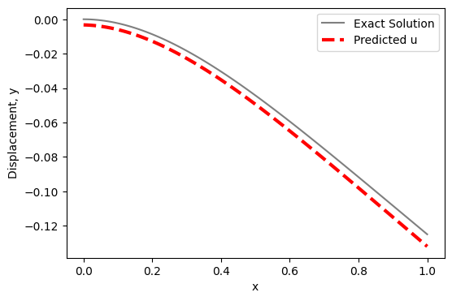

```python
x_ = np.linspace(0, 1, 100)
x_ = torch.tensor(x_.reshape(-1, 1), dtype=torch.float32)

with torch.no_grad():
    model.cpu()
    model.eval()
    u_ = model(x_)

plt.figure(figsize = (6, 4))
plt.plot(x_, exact_solution(x_), c =  'k', label = 'Exact Solution', alpha = 0.5)
plt.plot(x_, u_.detach().numpy(), c =  'r', label = 'Predicted u', linestyle = '--', linewidth = 3)
plt.legend(fontsize = 10)
plt.xticks(fontsize = 10)
plt.yticks(fontsize = 10)
plt.xlabel('x', fontsize = 10)
plt.ylabel('Displacement, y', fontsize = 10)
plt.show()
```

# 6. Lab 4: Thin Plate (Solid Mechanics)

So far, we have demonstrated the implementation of PINNs using Keras, DeepXDE, and PyTorch. By now, we hope you have gained a solid understanding of how to apply PINNs to solve differential equations. However, all the examples covered thus far have been one-dimensional problems.

Next, we extend our approach to a two-dimensional setting by addressing the thin plate displacement prediction problem. This will illustrate how PINNs adapt to higher-dimensional problems and highlight the additional complexities introduced when solving 2D partial differential equations.

## 6.1. Problem Setup

- We will solve thin plate equations to find displacement and stress distribution of thin plate in 2D
- Based on *Kirchhoff-Love* plate theory, three hypotheses were used
  - straight lines normal to the mid-surface remain straight after deformation
  - straight lines normal to the mid-surface remain normal to the mid-surface after deformation
  - the thickness of the plate does not change during a deformation
- A non-uniform stretching force is applied to square elastic plate
- Only one quarter of the plate is considered since the geometry and in-plane forces are symmetric (yellow domain)

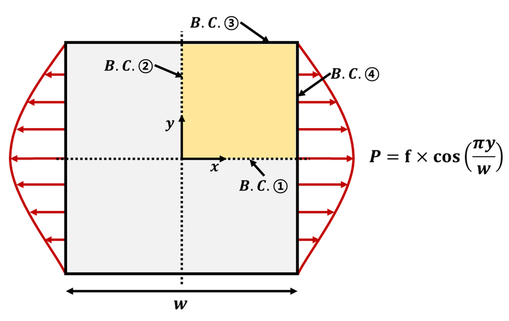

- Problem properties

$$ E = 50 \operatorname{Mpa}, \quad \nu = 0.3, \quad \omega = 20 \operatorname{mm}, \quad h = 1 \operatorname{mm}, \quad f = 1 \operatorname{Mpa} $$

- Governing equations (Föppl–von Kármán equations) for the isotropic elastic plate:

$$ \begin{align*} &{E \over 1 - \nu^2}\left({\partial^2 u \over \partial x^2} + {1 - \nu \over 2}{\partial^2 u \over \partial y^2} + {1 + \nu \over 2}{\partial^2 v \over \partial x \partial y} \right) = 0\\\\ &{E \over 1 - \nu^2}\left({\partial^2 v \over \partial y^2} + {1 - \nu \over 2}{\partial^2 v \over \partial x^2} + {1 + \nu \over 2}{\partial^2 x \over \partial x \partial y} \right) = 0 \end{align*} $$

- Two Dirichlet boundary conditions at $x = 0,\, y = 0\; (B.C.①, B.C.②)$:

$$ v(x,y) = 0 \qquad \text{at} \quad y = 0\\\\ u(x,y) = 0 \qquad \text{at} \quad x = 0 $$

- Two free boundary conditions at $y = \omega / 2\; (B.C.③)$:

$$ \sigma_{yy} = 0,\quad \sigma_{yx} = 0 $$

- Free boundary condition and in-plane force boundary condition at $x = \omega / 2\; (B.C.④)$:

$$\sigma_{xx} = P \cdot h,\quad \sigma_{xy} = 0$$

- Make a neural network and loss funcitons like below:

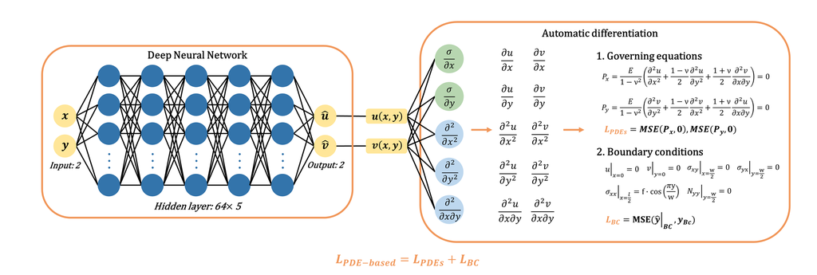

**Numerical Solution (= Exact Solution)**

- Numerical solution of this problem is illustrated in below figures
- $x, y$ direction displacement $u$, $v$ and
- Stress $\sigma_{xx}$ and $\sigma_{yy}$
- Solve this problem using PINN and then compare with a numerical solution

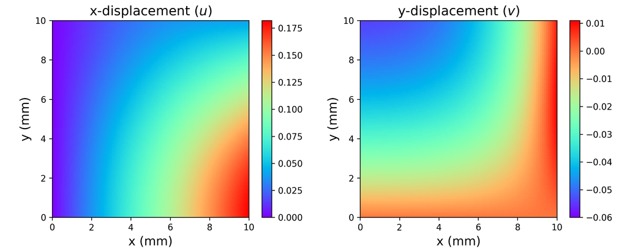

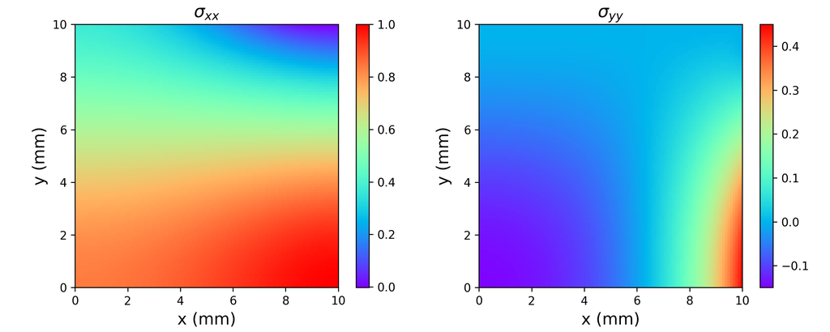

## 6.2. PINN as PDE Solver

**Import Library & Define Properties**

```python
import torch
import matplotlib.pyplot as plt
import numpy as np
import os

device = torch.device('cuda' if torch.cuda.is_available() else 'cpu')
print(device)
```

```
cuda
```

```python
# properties
E = 50.0
nu = 0.3
w = 10.0
f = 1.0
h = 1.0
```

**Define Collocation Points**

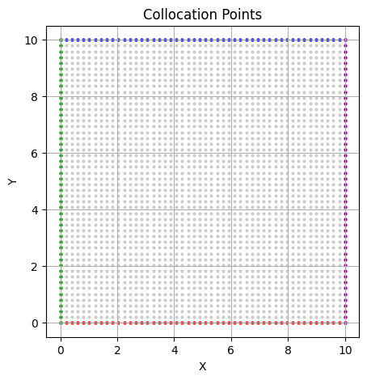

```python
Nx = 50                                            # Number of samples
Ny = 50                                            # Number of samples
x = torch.linspace(0, w, Nx)                       # Input data for x (Nx x 1)
y = torch.linspace(0, w, Ny)                       # Input data for y (Ny x 1)

xy = torch.meshgrid(x, y, indexing = 'ij')
XY_domain = torch.cat([xy[0].reshape(-1, 1), xy[1].reshape(-1, 1)], dim = 1)

XY_left = XY_domain[XY_domain[:, 0] == 0]
XY_right = XY_domain[XY_domain[:, 0] == w]
XY_top = XY_domain[XY_domain[:, 1] == w]
XY_bottom = XY_domain[XY_domain[:, 1] == 0]

plt.figure(figsize = (5, 5))
plt.scatter(XY_domain[:, 0], XY_domain[:, 1], s = 4, c = 'gray', alpha = 0.3)
plt.scatter(XY_bottom[:, 0], XY_bottom[:, 1], s = 4, c = 'red')
plt.scatter(XY_top[:, 0], XY_top[:, 1], s = 4, c = 'blue')
plt.scatter(XY_left[:, 0], XY_left[:, 1], s = 4, c = 'green')
plt.scatter(XY_right[:, 0], XY_right[:, 1], s = 4, c = 'purple')

plt.title('Collocation Points')
plt.xlabel('X')
plt.ylabel('Y')
plt.grid(True)
plt.show()
```

**Define Network and Hyper-parameters**

```python
import torch.nn as nn
from torch.nn import Linear, Tanh

class PINN(nn.Module):
    def __init__(self):
        super(PINN, self).__init__()
        self.net = nn.Sequential(
        Linear(2, 64),
        Tanh(),
        Linear(64, 64),
        Tanh(),
        Linear(64, 64),
        Tanh(),
        Linear(64, 64),
        Tanh(),
        Linear(64, 64),
        Tanh(),
        Linear(64, 64),
        Tanh(),
        Linear(64, 2)
        )

        self._initialize_weights()

    def _initialize_weights(self):
        for m in self.modules():
            if isinstance(m, nn.Linear):
                nn.init.xavier_normal_(m.weight)
                nn.init.zeros_(m.bias)

    def forward(self, x):
        x = x.float()
        output = self.net(x)
        u, v = output[:, 0:1], output[:, 1:2]
        return u, v

model = PINN().to(device)
optimizer = torch.optim.Adam(model.parameters(), lr = 1e-3)
loss_fn = nn.MSELoss()
```

**Define PDE with Boundary Conditions**

- Governing equations (Föppl-von Kármán equations) for the isotropic elastic plate:

$$ \begin{align*} &{E \over 1 - \nu^2}\left({\partial^2 u \over \partial x^2} + {1 - \nu \over 2}{\partial^2 u \over \partial y^2} + {1 + \nu \over 2}{\partial^2 v \over \partial x \partial y} \right) = 0\\\\ &{E \over 1 - \nu^2}\left({\partial^2 v \over \partial y^2} + {1 - \nu \over 2}{\partial^2 v \over \partial x^2} + {1 + \nu \over 2}{\partial^2 u \over \partial x \partial y} \right) = 0 \end{align*} $$

```python
def derivative(y, t) :
    df = torch.autograd.grad(y, t, grad_outputs = torch.ones_like(y).to(device), create_graph = True)[0]
    df_x = df[:, 0:1]
    df_y = df[:, 1:2]
    return df_x, df_y

def PDE(model, XY_domain):
    u, v = model(XY_domain)

    du_x, du_y = derivative(u, XY_domain)
    dv_x, dv_y = derivative(v, XY_domain)

    du_xx, du_xy = derivative(du_x, XY_domain)
    _, du_yy = derivative(du_y, XY_domain)

    dv_xx, dv_xy = derivative(dv_x, XY_domain)
    _, dv_yy = derivative(dv_y, XY_domain)

    factor = E / (1 - nu ** 2)

    force_eq_x = factor * (du_xx + (1 - nu) / 2 * du_yy + (1 + nu) / 2 * dv_xy)
    force_eq_y = factor * (dv_yy + (1 - nu) / 2 * dv_xx + (1 + nu) / 2 * du_xy)

    return force_eq_x.float(), force_eq_y.float()
```

$$ \begin{align*} v(x,y) &= 0 \qquad \text{at} \quad y = 0 \text{: (bottom)} \\ \\ u(x,y) &= 0 \qquad \text{at} \quad x = 0 \text{: (left)} \end{align*} $$

```python
def BC_left(model, left):
    u_left, _ = model(left)
    return u_left

def BC_bottom(model, bottom):
    _, v_bottom = model(bottom)
    return v_bottom
```

- Two free boundary conditions at $y = \omega / 2\; (B.C.③ \text{ (top)})$:

$$ \sigma_{yy} = 0,\quad \sigma_{yx} = 0 $$

- Free boundary condition and in-plane force boundary condition at $x = \omega / 2\; (B.C.④ \text{ (right)})$:

$$ \begin{align*} \sigma_{xx} &= P \cdot h \\ \sigma_{xy} &= 0 \end{align*} $$

- Stress

$$ \begin{align*} \sigma_{xx} &= \frac{E}{1 - \nu^2} \left( \frac{\partial u}{\partial x} + \nu \frac{\partial v}{\partial y} \right) \\ \sigma_{yy} &= \frac{E}{1 - \nu^2} \left( \frac{\partial v}{\partial y} + \nu \frac{\partial u}{\partial x} \right)\\ \sigma_{xy} &= \sigma_{yx} = \frac{E}{2(1 + \nu)} \left( \frac{\partial v}{\partial x} + \frac{\partial u}{\partial y} \right) \end{align*} $$

```python
def BC_top(model, top):
    # Top edge
    u_top, v_top = model(top)

    u_top_x, u_top_y = derivative(u_top, top)
    v_top_x, v_top_y = derivative(v_top, top)

    sigma_yy = E / (1 - nu ** 2) * (v_top_y + nu * u_top_x)
    sigma_yx = E / (2 * (1 + nu)) * (v_top_x + u_top_y)
    return sigma_yy, sigma_yx

def BC_right(model, right):
    # Right edge
    u_right, v_right = model(right)

    u_right_x, u_right_y = derivative(u_right, right)
    v_right_x, v_right_y = derivative(v_right, right)

    sigma_xx = E / (1 - nu ** 2) * (u_right_x + nu * v_right_y)
    sigma_xy = E / (2 * (1 + nu)) * ((v_right_x + u_right_y))

    sigma_ex = h * f * torch.cos(np.pi * right[:, 1:] / (2 * w))
    return sigma_xx, sigma_ex, sigma_xy
```

**Train**

Training a PINN can be computationally expensive and time-consuming. To facilitate experimentation and reproducibility, we provide a trained model along with its corresponding parameters. This allows you to directly evaluate and analyze the results without waiting for extended training times. However, if needed, you can still train the model to explore its behavior further.

```python
def require_grad(x):
    return torch.tensor(x, dtype = torch.float32, requires_grad = True).to(device)
```

```python
XY_domain = require_grad(XY_domain)
XY_bottom = require_grad(XY_bottom)
XY_top = require_grad(XY_top)
XY_left = require_grad(XY_left)
XY_right = require_grad(XY_right)

epochs = 10001

for epoch in range(epochs):

    force_eq_x, force_eq_y = PDE(model, XY_domain)
    loss_PDE_x = loss_fn(force_eq_x, torch.zeros_like(force_eq_x))
    loss_PDE_y = loss_fn(force_eq_y, torch.zeros_like(force_eq_y))
    loss_PDE = loss_PDE_x + loss_PDE_y

    bottom_v = BC_bottom(model, XY_bottom)
    left_u = BC_left(model, XY_left)
    top_sigyy, top_sigyx = BC_top(model, XY_top)
    right_sigxx, right_sigex, right_sigxy = BC_right(model, XY_right)

    loss_BC_bottom = loss_fn(bottom_v, torch.zeros_like(bottom_v))

    loss_BC_left = loss_fn(left_u, torch.zeros_like(left_u))

    loss_BC_top_1 = loss_fn(top_sigyy, torch.zeros_like(top_sigyy))
    loss_BC_top_2 = loss_fn(top_sigyx, torch.zeros_like(top_sigyx))
    loss_BC_top = loss_BC_top_1 + loss_BC_top_2

    loss_BC_right_1 = loss_fn(right_sigxx, right_sigex)
    loss_BC_right_2 = loss_fn(right_sigxy, torch.zeros_like(right_sigxy))
    loss_BC_right = loss_BC_right_1 + loss_BC_right_2

    loss_BC = loss_BC_bottom + loss_BC_left + loss_BC_top + loss_BC_right

    loss = loss_PDE + loss_BC

    optimizer.zero_grad()
    loss.backward()
    optimizer.step()

    if epoch % 1000 == 0:
        print('Epoch: {} Loss: {:.4f} PDELoss: {:.4f} BCLoss: {:.4f}'.\
              format(epoch, loss.item(), loss_PDE.item(), loss_BC.item()))
```

```
Epoch: 0 Loss: 14.9388 PDELoss: 3.2198 BCLoss: 11.7190
Epoch: 1000 Loss: 0.0020 PDELoss: 0.0011 BCLoss: 0.0009
Epoch: 2000 Loss: 0.0012 PDELoss: 0.0007 BCLoss: 0.0005
Epoch: 3000 Loss: 0.0010 PDELoss: 0.0005 BCLoss: 0.0005
Epoch: 4000 Loss: 0.0006 PDELoss: 0.0003 BCLoss: 0.0002
Epoch: 5000 Loss: 0.0003 PDELoss: 0.0002 BCLoss: 0.0001
Epoch: 6000 Loss: 0.0002 PDELoss: 0.0001 BCLoss: 0.0001
Epoch: 7000 Loss: 0.0011 PDELoss: 0.0003 BCLoss: 0.0008
Epoch: 8000 Loss: 0.0001 PDELoss: 0.0001 BCLoss: 0.0001
Epoch: 9000 Loss: 0.0004 PDELoss: 0.0001 BCLoss: 0.0003
Epoch: 10000 Loss: 0.0003 PDELoss: 0.0000 BCLoss: 0.0003
```

**Load the Model Parameters**

The trained model will be used to avoid the long training time.

- [lab2_adam_model.pt](https://drive.google.com/file/d/1yFTSEGeqCP-FDez6jLYK29auqYF2GkEB/view?usp=sharing)

```python
from google.colab import drive
drive.mount('/content/drive')
```

```python
# GPU available
if torch.cuda.is_available():
    model = torch.load('/content/drive/MyDrive/DL/DL_data/lab2_adam_model.pt')
```

**Plot Displacement and Stress**

```python
def check_stress(model, xy):
    u, v = model(xy)

    u_x, _ = derivative(u, xy)
    _, v_y = derivative(v, xy)

    sig_xx = E / (1 - nu ** 2) * (u_x + nu * v_y)
    sig_yy = E / (1 - nu ** 2) * (v_y + nu * u_x)

    return sig_xx, sig_yy

def plot_results(data, color_legend, titles, w):
    plt.figure(figsize = (8, 3))
    for idx in range(2):
        plt.subplot(1, 2, idx + 1)
        plt.scatter(test[:, 0], test[:, 1],
                    c = data[idx].detach().cpu().numpy(),
                    cmap = 'rainbow',
                    s = 5)
        plt.clim(color_legend[idx])
        plt.title(titles[idx])
        plt.axis('square')
        plt.xlim((0, w))
        plt.ylim((0, w))
        plt.colorbar()

    plt.tight_layout()
    plt.show()
```

```python
Nx = 100                                            # Number of samples
Ny = 100                                            # Number of samples
x_test = torch.linspace(0, w, Nx)                   # Input data for x (Nx x 1)
y_test = torch.linspace(0, w, Ny)                   # Input data for y (Ny x 1)

xy_test = torch.meshgrid(x_test, y_test)
test = torch.cat([xy_test[0].reshape(-1, 1), xy_test[1].reshape(-1, 1)], dim = 1)

test_tensor = require_grad(test)

with torch.no_grad():
    model.eval()
    result = model(test_tensor)

sigma_xx, sigma_yy = check_stress(model, test_tensor)
sigma = [sigma_xx, sigma_yy]
```

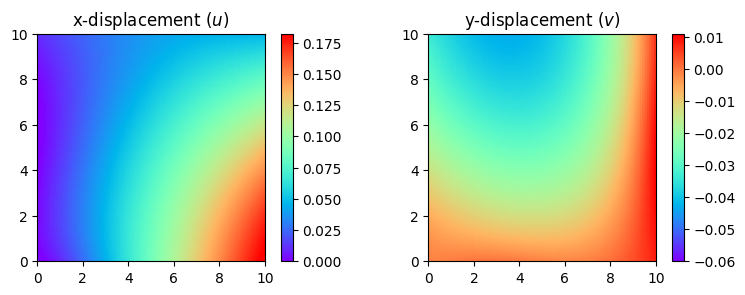

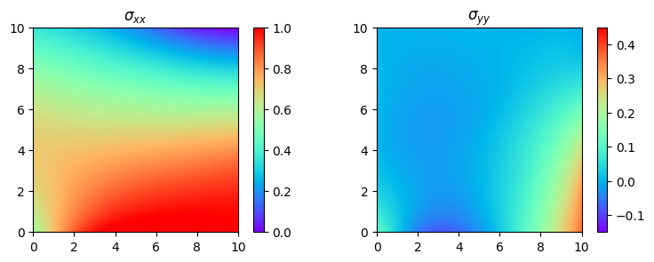

```python
titles = ['x-displacement ($u$)', 'y-displacement ($v$)',
          '$\sigma_{xx}$', '$\sigma_{yy}$']

color_legend = [[0, 0.182], [-0.06, 0.011], [-0.0022, 1.0], [-0.15, 0.45]]

plot_results(result, color_legend[:2], titles[:2], w)
plot_results(sigma, color_legend[2:], titles[2:], w)
```

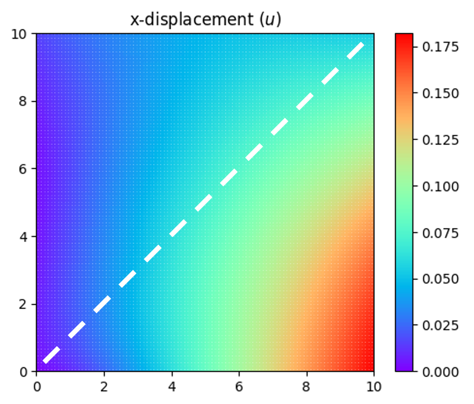

- [lab2_Plate Data](https://drive.google.com/file/d/1J80didBUGt0Cts6HTk1KNmGqMNQWR4Uf/view?usp=sharing)

```python
Plate_data = np.load('/content/drive/MyDrive/DL/DL_data/lab2_Plate_data.npy')

loc = Plate_data[:, 0:2]
u = Plate_data[:, 2:3]
v = Plate_data[:, 3:4]
stress = Plate_data[:, 4:6]
```

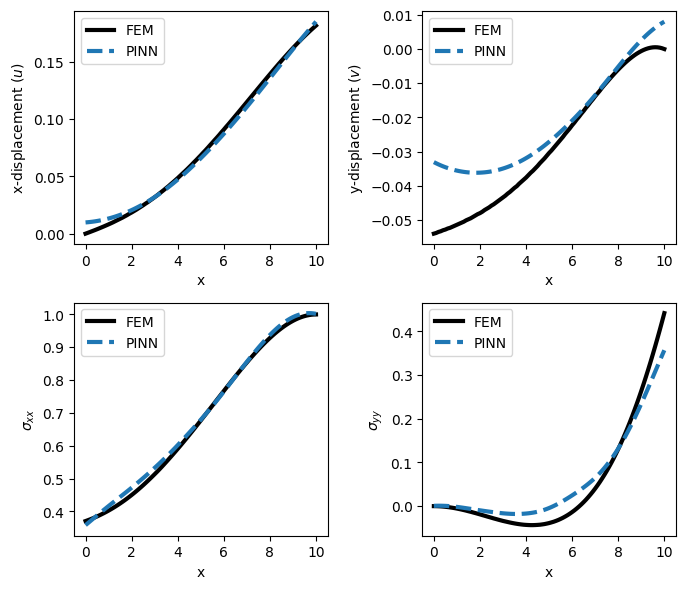

```python
def RESULT(test_model, diag):
    diag = require_grad(diag)
    pde_u, pde_v = test_model(diag)
    pde_disp = np.hstack([pde_u.cpu().detach().numpy(), pde_v.cpu().detach().numpy()])
    sig_x, sig_y = check_stress(test_model, diag)
    pde_sig = np.hstack([sig_x.cpu().detach().numpy(), sig_y.cpu().detach().numpy()])
    return pde_disp, pde_sig

diag_ = [i for i in range(u.shape[0]) if loc[i, 0] + loc[i, 1] == 10]
diag_x = np.linspace(0, 10, 101).reshape(-1, 1)
diag_y = -diag_x + 10
diag = np.concatenate((diag_x, diag_y), 1)

model_Adam = torch.load('/content/drive/MyDrive/DL/DL_data/lab2_adam_model.pt')

results = {
    "FEM": [u[diag_], v[diag_], stress[diag_, 0], stress[diag_, 1]],
    "PINN": RESULT(model_Adam, diag),
}

for key in ["PINN"]:
    disp, sig = results[key]
    results[key] = [disp[:, 0], disp[:, 1], sig[:, 0], sig[:, 1]]

titles = ['x-displacement ($u$)', 'y-displacement ($v$)', '$\sigma_{xx}$', '$\sigma_{yy}$']
line_styles = {'FEM': 'k', 'PINN': '--'}

plt.figure(figsize = (7, 6))

for idx, title in enumerate(titles):
    plt.subplot(2, 2, idx + 1)
    for label, result in results.items():
        plt.plot(diag[:, 0], result[idx], line_styles[label], linewidth = 3, label = label)

    plt.xlabel('x')
    plt.ylabel(title)
    plt.legend()

plt.tight_layout()
plt.show()
```

## 6.3. PINN + **Data**

The results for y-displacement and y-direction stress deviate slightly from the ground truth. To improve the prediction performance, we could further optimize the hyperparameters or increase the number of collocation points. However, instead of focusing on these conventional optimization techniques, we will introduce a different approach to enhance accuracy.

Assume that observed data is available, such as displacement values obtained from physical sensors placed on the thin plate or extracted from CAE results. Incorporating such observed data into the Physics-informed Neural Network (PINN) framework can significantly improve predictive accuracy. In the following section, we will demonstrate how to integrate observed data into a PINN and examine how it contributes to enhanced model performance.

- Adding constraints for regularization

$$ \begin{align*} \mathcal{L} &= \omega_{\text{data}} \mathcal{L}_{\text{data}} + \omega_{\text{PDE}} \mathcal{L}_{\text{PDE}} + \omega_{\text{BC}} \mathcal{L}_{\text{BC}}\\\\\\ \mathcal{L}_{\text{data}} &= \frac{1}{N_{\text{data}}} \sum \left(u - \hat u \right)^2 \\ \end{align*} $$

**Define Observed Data**

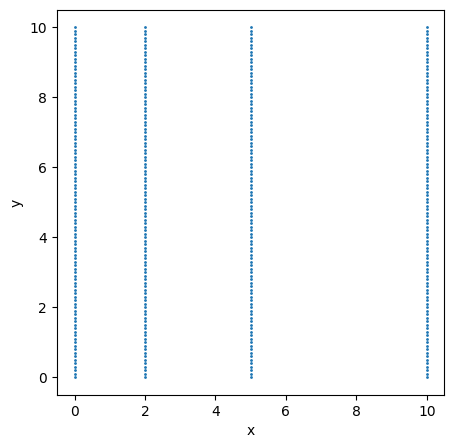

```python
x_values = [0, 2, 5, 10]
tr_sample = np.where(np.isin(loc[:, 0], x_values))[0]

x_sample = loc[tr_sample, :]
u_sample = u[tr_sample, :]
v_sample = v[tr_sample, :]
stress_sample = stress[tr_sample, :]

data = np.concatenate([x_sample, u_sample, v_sample, stress_sample], axis = 1)

plt.figure(figsize = (5, 5))
plt.scatter(x_sample[:, 0], x_sample[:, 1], s = 1)
plt.xlim([-0.5, 10.5])
plt.xlabel('x')
plt.ylabel('y')
plt.show()
```

**Define Data-Driven Loss Term**

```python
def DATA(model, loc):
    u, v = model(loc)
    u_x, _ = derivative(u, loc)
    _, v_y = derivative(v, loc)
    sigma_xx = E / (1 - nu ** 2) * (u_x + nu * v_y)
    sigma_yy = E / (1 - nu ** 2) * (v_y + nu * u_x)
    sigma = torch.cat((sigma_xx, sigma_yy), dim = 1)
    return u, v, sigma
```

**Train**

```python
model = PINN().to(device)
optimizer = torch.optim.Adam(model.parameters(), lr = 1e-3)

loss_fn = nn.MSELoss()

epochs = 10001

loc = require_grad(data[:, 0:2])
gt_u = require_grad(data[:, 2:3])
gt_v = require_grad(data[:, 3:4])
gt_sigma = require_grad(data[:, 4:6])

for epoch in range(epochs):

    # PDE
    force_eq_x, force_eq_y = PDE(model, XY_domain)
    loss_PDE_x = loss_fn(force_eq_x, torch.zeros_like(force_eq_x))
    loss_PDE_y = loss_fn(force_eq_y, torch.zeros_like(force_eq_y))
    loss_PDE = loss_PDE_x + loss_PDE_y

    # BC
    bottom_v = BC_bottom(model, XY_bottom)
    left_u = BC_left(model, XY_left)
    top_sigyy, top_sigyx = BC_top(model, XY_top)
    right_sigxx, right_sigex, right_sigxy = BC_right(model, XY_right)

    loss_BC_bottom = loss_fn(bottom_v, torch.zeros_like(bottom_v))

    loss_BC_left = loss_fn(left_u, torch.zeros_like(left_u))

    loss_BC_top_1 = loss_fn(top_sigyy, torch.zeros_like(top_sigyy))
    loss_BC_top_2 = loss_fn(top_sigyx, torch.zeros_like(top_sigyx))
    loss_BC_top = loss_BC_top_1 + loss_BC_top_2

    loss_BC_right_1 = loss_fn(right_sigxx, right_sigex)
    loss_BC_right_2 = loss_fn(right_sigxy, torch.zeros_like(right_sigxy))
    loss_BC_right = loss_BC_right_1 + loss_BC_right_2

    loss_BC = loss_BC_bottom + loss_BC_left + loss_BC_top + loss_BC_right

    # DATA
    data_u, data_v, data_sigma = DATA(model, loc)
    loss_Data_u = loss_fn(data_u, gt_u)
    loss_Data_v = loss_fn(data_v, gt_v)
    loss_Data_sigma = loss_fn(data_sigma, gt_sigma)

    loss_Data = loss_Data_u + loss_Data_v + loss_Data_sigma

    # Total
    loss = loss_PDE + loss_BC + loss_Data

    optimizer.zero_grad()
    loss.backward()
    optimizer.step()

    if epoch % 1000 == 0:
        print('Epoch: {} Loss: {:.4f} PDELoss: {:.4f} BCLoss: {:.4f} DATALoss: {:.4f}'.\
              format(epoch, loss.item(), loss_PDE.item(), loss_BC.item(), loss_Data.item()))
```

```
Epoch: 0 Loss: 29.9112 PDELoss: 5.4634 BCLoss: 2.1046 DATALoss: 22.3431
Epoch: 1000 Loss: 0.0053 PDELoss: 0.0020 BCLoss: 0.0017 DATALoss: 0.0016
Epoch: 2000 Loss: 0.0015 PDELoss: 0.0009 BCLoss: 0.0004 DATALoss: 0.0002
Epoch: 3000 Loss: 0.0007 PDELoss: 0.0005 BCLoss: 0.0001 DATALoss: 0.0001
Epoch: 4000 Loss: 0.0003 PDELoss: 0.0002 BCLoss: 0.0001 DATALoss: 0.0000
Epoch: 5000 Loss: 0.0002 PDELoss: 0.0002 BCLoss: 0.0000 DATALoss: 0.0000
Epoch: 6000 Loss: 0.0002 PDELoss: 0.0001 BCLoss: 0.0000 DATALoss: 0.0000
Epoch: 7000 Loss: 0.0001 PDELoss: 0.0001 BCLoss: 0.0000 DATALoss: 0.0000
Epoch: 8000 Loss: 0.0001 PDELoss: 0.0001 BCLoss: 0.0000 DATALoss: 0.0000
Epoch: 9000 Loss: 0.0001 PDELoss: 0.0001 BCLoss: 0.0000 DATALoss: 0.0000
Epoch: 10000 Loss: 0.0001 PDELoss: 0.0001 BCLoss: 0.0000 DATALoss: 0.0000
```

**Load the model parameters**

- [lab2_data_model.pt](https://drive.google.com/file/d/10t30Bv0BT4c8VJ9W5xTadnOUxHLdUzbH/view?usp=sharing)

**Plot Results**

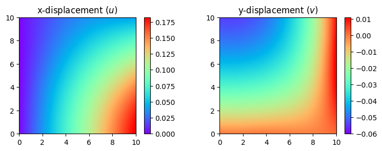

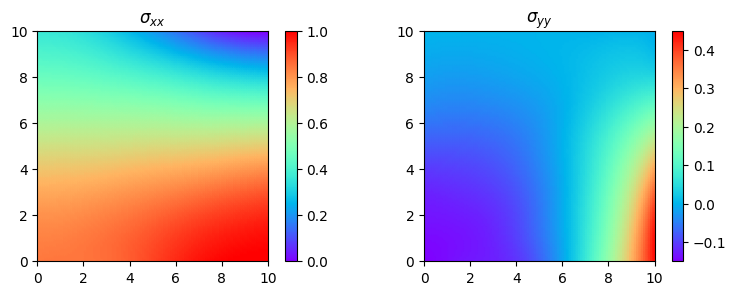

```python
with torch.no_grad():
    model = torch.load('/content/drive/MyDrive/DL/DL_data/lab2_data_model.pt')
    result = model(test_tensor)

sigma_xx, sigma_yy = check_stress(model, test_tensor)
sigma = [sigma_xx, sigma_yy]

plot_results(result, color_legend[:2], titles[:2], w)
plot_results(sigma, color_legend[2:], titles[2:], w)
```

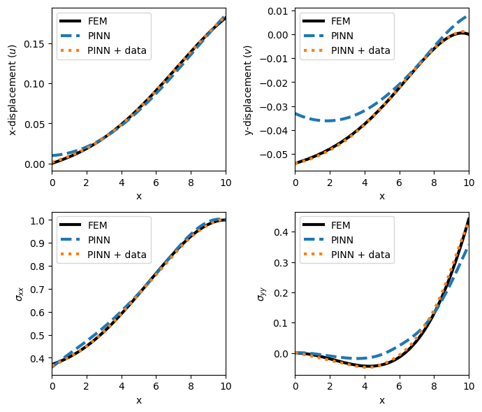

```python
loc = Plate_data[:, 0:2]
u = Plate_data[:, 2:3]
v = Plate_data[:, 3:4]
stress = Plate_data[:, 4:6]

def RESULT(test_model, diag):
    diag = require_grad(diag)
    pde_u, pde_v = test_model(diag)
    pde_disp = np.hstack([pde_u.cpu().detach().numpy(), pde_v.cpu().detach().numpy()])
    sig_x, sig_y = check_stress(test_model, diag)
    pde_sig = np.hstack([sig_x.cpu().detach().numpy(), sig_y.cpu().detach().numpy()])
    return pde_disp, pde_sig

diag_ = [i for i in range(u.shape[0]) if loc[i, 0] + loc[i, 1] == 10]
diag_x = np.linspace(0, 10, 101).reshape(-1, 1)
diag_y = -diag_x + 10
diag = np.concatenate((diag_x, diag_y), 1)

model_Adam = torch.load('/content/drive/MyDrive/DL/DL_data/lab2_adam_model.pt')
model_Data = torch.load('/content/drive/MyDrive/DL/DL_data/lab2_data_model.pt')

results = {
    "FEM": [u[diag_], v[diag_], stress[diag_, 0], stress[diag_, 1]],
    "PINN": RESULT(model_Adam, diag),
    "PINN + data": RESULT(model_Data, diag)
}

for key in ["PINN", "PINN + data"]:
    disp, sig = results[key]
    results[key] = [disp[:, 0], disp[:, 1], sig[:, 0], sig[:, 1]]

titles = ['x-displacement ($u$)', 'y-displacement ($v$)', '$\sigma_{xx}$', '$\sigma_{yy}$']
line_styles = {'FEM': 'k', 'PINN': '--', 'PINN + data': ':'}

plt.figure(figsize = (7, 6))

for idx, title in enumerate(titles):
    plt.subplot(2, 2, idx + 1)
    for label, result in results.items():
        plt.plot(diag[:, 0], result[idx], line_styles[label], linewidth = 3, label = label)
    plt.xlabel('x')
    plt.ylabel(title)
    plt.xlim((0, 10))
    plt.legend()

plt.tight_layout()
plt.show()
```

From this example, we can learn two key lessons:

1. How to incorporate observational data into the PINN model.
2. When available, leveraging data enhances the performance of PINNs, making the approach more effective and generally recommended.